# Mini-Project #02: The Business of Show Business

In this project, we will analyze the Hollywood history and get data-driven ideas for a “new movie” by defining best genres, actors, directors of a decade, all the time and assign special weighted score that will help us to identify the secret of a successful sauce to make the catchy and appealing movie for the nowadays audience. Let’s begin!

The key data source that will be used is the [Internet Movie Database (IMDb) for non-commercial use](https://datasets.imdbws.com/).

Note: *All answers are provided from a large IMDb dataset that I run locally. However the code in this Quarto file uses compressed data from [here](https://github.com/michaelweylandt/STA9750/tree/main/miniprojects/mini02_preprocessed/). So some charts might be influenced and you can see differneces (e.g. you will notice that moving chart data for 2020 a bit corrupt).*

## Before we start

### 1) Import libraries

The first step before you start doing anything on your project is to make sure that you have all your packages installed. However, don’t be worried if you miss any, you can add them anywhere in the code, but for readability and clean code writing you should build that habit of importing everything when you start. While we are familiar already with the most of the packages I will add only two comments for new ones.

Note: The code will be collapsed for better navigation.

**Import Libraries**

```r
library(readr)
library(dplyr)
library(stringr)
library(ggplot2)
library(scales)
library(tidyr)
library(knitr) #improves readability of outputs
library(kableExtra) #addition to knitr, styling tables in R Markdown documents
#install.packages("kableExtra") #if it didn't import, do install command
```

### 2) Import the dataset

It might take some time to download it and several times I caught myself on thought that R Studio was not working, but it was. Just give it a time, some of the datasets have more than 3M rows!

**Import IMDb Data**

```r
get_imdb_file <- function(filename) {
  base_url <- "https://raw.githubusercontent.com/michaelweylandt/STA9750/main/miniprojects/mini02_preprocessed/"

  file_url <- paste0(base_url, filename, ".csv.zip")
  dest_file <- paste0("data/", filename, ".csv.zip")

  if (!dir.exists("data")) {
    dir.create("data")
  }

  if (!file.exists(dest_file)) {
    download.file(file_url, destfile = dest_file, mode = "wb")
  }
  data <- readr::read_csv(dest_file)
  return(data)
}

NAME_BASICS      <- get_imdb_file("name_basics_small")
TITLE_BASICS     <- get_imdb_file("title_basics_small")
TITLE_EPISODES   <- get_imdb_file("title_episodes_small")
TITLE_RATINGS    <- get_imdb_file("title_ratings_small")
TITLE_CREW       <- get_imdb_file("title_crew_small")
TITLE_PRINCIPALS <- get_imdb_file("title_principals_small")
```

After this step we will start our EDA(explanatory data analysis)

[figure not shown]

Source: geeksforgeeks.org

### 3) **Data Sub-Sampling**

We will sample our data to smaller chunks for this analysis and will use “knownForTites” names assigned by IMDb and Titles that have more than 100 ratings as we don’t need anything lower for finding the best samples to follow for our movie idea. As well we will do a semi-join to return only the values that have a match and doesn’t add collumns.

**Data Sub-Sampling**

[figure not shown]

```r
NAME_BASICS <- NAME_BASICS |>
    filter(str_count(knownForTitles, ",") > 1)
TITLE_RATINGS |>
    ggplot(aes(x=numVotes)) +
    geom_histogram(bins=30) +
    xlab("Number of IMDB Ratings") +
    ylab("Number of Titles") +
    ggtitle("Majority of IMDB Titles Have Less than 100 Ratings") +
    theme_bw() +
    scale_x_log10(label=scales::comma) +
    scale_y_continuous(label=scales::comma)
```

**Data Sub-Sampling**

```r
TITLE_RATINGS |>
    pull(numVotes) |>
    quantile()
```

```
     0%     25%     50%     75%    100%
    100     165     332     970 2942823
```

**Data Sub-Sampling**

```r
TITLE_RATINGS <- TITLE_RATINGS |>
    filter(numVotes >= 100)
#semi-join
TITLE_BASICS <- TITLE_BASICS |>
    semi_join(TITLE_RATINGS,
              join_by(tconst == tconst))

TITLE_CREW <- TITLE_CREW |>
    semi_join(TITLE_RATINGS,
              join_by(tconst == tconst))

TITLE_EPISODES_1 <- TITLE_EPISODES |>
    semi_join(TITLE_RATINGS,
              join_by(tconst == tconst))
TITLE_EPISODES_2 <- TITLE_EPISODES |>
    semi_join(TITLE_RATINGS,
              join_by(parentTconst == tconst))

TITLE_EPISODES <- bind_rows(TITLE_EPISODES_1,
                            TITLE_EPISODES_2) |>
    distinct()

TITLE_PRINCIPALS <- TITLE_PRINCIPALS |>
    semi_join(TITLE_RATINGS, join_by(tconst == tconst))


rm(TITLE_EPISODES_1)
rm(TITLE_EPISODES_2)
```

### 4) Data Cleaning

In this step, we will correct the column types of the `TITLE` tables using a combination of `mutate` and the coercion functions `as.numeric` and `as.logical`.

**NAME_BASICS Example**

```r
NAME_BASICS <- NAME_BASICS |>
    mutate(birthYear = as.numeric(birthYear),
           deathYear = as.numeric(deathYear))
```

Before we will change all types it’s useful to check what is your data with `glimpse` function.

**Glimpse Example**

```r
# glimpse(NAME_BASICS)
# glimpse(TITLE_BASICS)
# glimpse(TITLE_EPISODES)
# glimpse(TITLE_RATINGS)
# glimpse(TITLE_CREW)
# glimpse(TITLE_PRINCIPALS)
```

Another good function is `separate_longer_delim` that helps to break view into multiple rows, here’s the example:

**Separate_longer_delim function**

```r
# NAME_BASICS |> separate_longer_delim(knownForTitles, ",") |> slice_head(n=10)
```

Here’s a small schema that shows all connections between the tables.

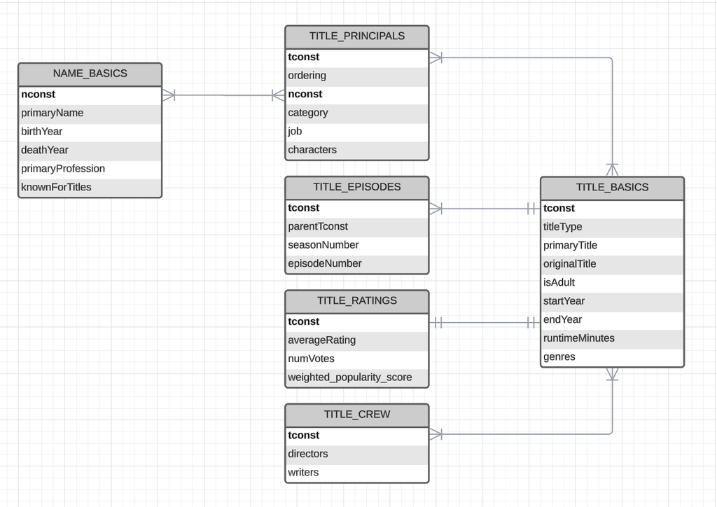

#### Task 1. Correct all TITLE tables

```r
TITLE_BASICS <- TITLE_BASICS |>
    mutate(startYear = as.numeric(startYear),
           endYear = as.numeric(endYear),
           isAdult = as.logical(as.numeric(isAdult))
           )
TITLE_EPISODES <- TITLE_EPISODES |>
    mutate(seasonNumber = as.numeric(seasonNumber),
           episodeNumbers = as.numeric(episodeNumber))
TITLE_RATINGS <- TITLE_RATINGS |>
    mutate(averageRating = as.numeric(averageRating),
           numVotes = as.numeric(numVotes))
TITLE_CREW <- TITLE_CREW |>
    mutate(directors = as.character(directors),
           writers = as.character(writers))
TITLE_PRINCIPALS <- TITLE_PRINCIPALS |>
    mutate(ordering = as.numeric(ordering),
           category = as.character(category),
           job = as.character(job),
           characters =as.character(characters))
```

After we wrangled and cleaned our dataset we can proceed to simple data manipulations and answer some questions!

#### Task 2. Bunch of dataset questions

#### 1) How many movies are in our data set? How many TV series? How many TV episodes?

[output not shown]

**Question 1 Code**

```r
TITLE_BASICS |>
  group_by(titleType) |>
  summarise(count = n())
```

```
# A tibble: 10 × 2
   titleType     count
   <chr>         <int>
 1 movie        131662
 2 short         16656
 3 tvEpisode    155722
 4 tvMiniSeries   5907
 5 tvMovie       15007
 6 tvSeries      29789
 7 tvShort         410
 8 tvSpecial      3045
 9 video          9332
10 videoGame      4668
```

#### 2) Who is the oldest living person in our data set?

Answer: **Traudl Lessing** was born in 1625.

**Question 2 Code**

```r
oldest_person <- NAME_BASICS |>
  filter(is.na(deathYear)) |>
  filter(birthYear == min(birthYear, na.rm = TRUE)) |>
  select(primaryName,birthYear)
```

#### 3) There is one TV Episode in this data set with a perfect 10/10 rating and 200,000 IMDb ratings. What is it? What series does it belong to?

Answer: **Ozymandias**

**Question 3 Code**

```r
best_episode <- TITLE_RATINGS |>
  filter(averageRating == 10, numVotes >= 200000) |>
  inner_join(TITLE_BASICS, by = "tconst") |>
  select(primaryTitle, titleType)
```